# Counting Correct Curls: Telemetry and Form in Weightlifting

Larkin O’Hern

September 4, 2016

### The Data:

The data for the this analysis were generously made available by Velloso, E.; Bulling, A.; Gellersen, H.; Ugulino, W.; Fuks, H. and more information as well as the datasets is available [here](http://groupware.les.inf.puc-rio.br/har#sbia_paper_section). The data consist of 19622 observations of 30 variables. The variables captured telemetry data from a large number of monitors worn by the subjects and, critically, were marked according to the ‘classe’ of curl being performed. Each classe corresponds to one of five common form types. The observations were distributed relatively evenly across the five types though as the table shows-classe A is somewhat over represented.

### Cross Validation

Before I did any exploratory analysis is split the data into training and test sets with 70% of the data in the training set and30% in the test set.

5580, 3797, 3422, 3216, 3607

### The Models:

I started with a tree model because I appreciate the interpretability-especially early on in a project. However, my tree models never got much above 50% accuracy-even on the training data. However, given five evenly distributed classes that’s still a more than 2X improvement of randomly assigning a classe.

The plot below maps the tree logic and the confusion matrix breaks out the accuracy by classe.

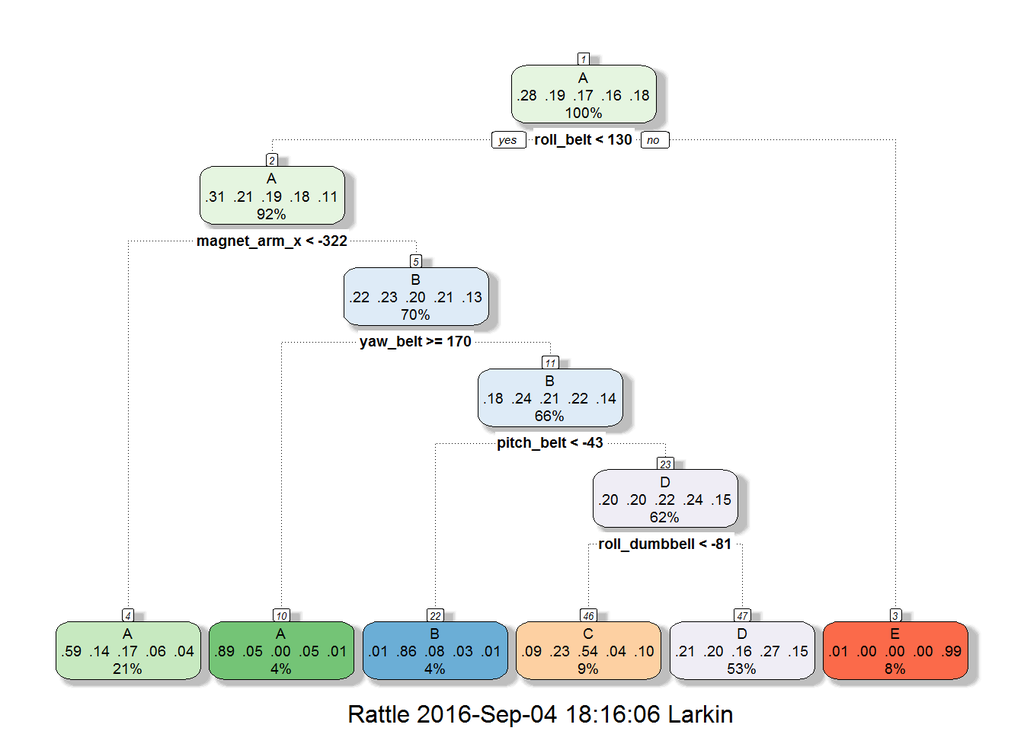

```
##           cp  Accuracy      Kappa AccuracySD    KappaSD
## 1 0.02776930 0.4867015 0.33967509 0.04048005 0.06844565
## 2 0.02812532 0.4860073 0.33880375 0.03962504 0.06763170
## 3 0.11463737 0.3349858 0.07703801 0.03874717 0.05905540
```

```
## Confusion Matrix and Statistics
##
##
## rpart_predicts   A   B   C   D   E
##              A 955 195 210  84  45
##              B   4 170  19   3   6
##              C  60 125 321  22  53
##              D 651 649 476 855 484
##              E   4   0   0   0 494
##
## Overall Statistics
##
##                Accuracy : 0.4749
##                  95% CI : (0.4621, 0.4878)
##     No Information Rate : 0.2845
##     P-Value [Acc > NIR] : < 2.2e-16
##
##                   Kappa : 0.3452
##  Mcnemar's Test P-Value : < 2.2e-16
##
## Statistics by Class:
##
##                      Class: A Class: B Class: C Class: D Class: E
## Sensitivity            0.5705  0.14925  0.31287   0.8869  0.45656
## Specificity            0.8732  0.99326  0.94649   0.5407  0.99917
## Pos Pred Value         0.6414  0.84158  0.55250   0.2745  0.99197
## Neg Pred Value         0.8364  0.82949  0.86708   0.9606  0.89085
## Prevalence             0.2845  0.19354  0.17434   0.1638  0.18386
## Detection Rate         0.1623  0.02889  0.05455   0.1453  0.08394
## Detection Prevalence   0.2530  0.03432  0.09873   0.5293  0.08462
## Balanced Accuracy      0.7218  0.57126  0.62968   0.7138  0.72786
```

```
## Confusion Matrix and Statistics
##
##
## svm_testing_preds    A    B    C    D    E
##                 A 1516  144   53   32    5
##                 B   45  870   60   34   41
##                 C   56   89  857   91   22
##                 D   40   23   47  798   48
##                 E   17   13    9    9  966
##
## Overall Statistics
##
##                Accuracy : 0.8508
##                  95% CI : (0.8414, 0.8598)
##     No Information Rate : 0.2845
##     P-Value [Acc > NIR] : < 2.2e-16
##
##                   Kappa : 0.811
##  Mcnemar's Test P-Value : < 2.2e-16
##
## Statistics by Class:
##
##                      Class: A Class: B Class: C Class: D Class: E
## Sensitivity            0.9056   0.7638   0.8353   0.8278   0.8928
## Specificity            0.9444   0.9621   0.9469   0.9679   0.9900
## Pos Pred Value         0.8663   0.8286   0.7686   0.8347   0.9527
## Neg Pred Value         0.9618   0.9444   0.9646   0.9663   0.9762
## Prevalence             0.2845   0.1935   0.1743   0.1638   0.1839
## Detection Rate         0.2576   0.1478   0.1456   0.1356   0.1641
## Detection Prevalence   0.2974   0.1784   0.1895   0.1624   0.1723
## Balanced Accuracy      0.9250   0.8630   0.8911   0.8978   0.9414
```

```
##
##    A    B    C    D    E
## 1674 1139 1026  964 1082
```

```
## svm_testing_preds
##    A    B    C    D    E
## 1750 1050 1115  956 1014
```

```
## rpart_predicts
##    A    B    C    D    E
## 1489  202  581 3115  498
```